# Análisis general: distribución de ingresos para la población de Cali, Valle del Cauca

Proyecto de movilidad

2022-11-11

# Método de imputación sobre los ingresos corrientes en la Gran Encuestra Integrada de Hogares (GEIH) 2022

# Metodología: imputación múltiple mediante coincidencia de media predictiva

Por definición, la imputación múltiple corresponde a un método de imputación fundamentado en la siguiente hipótesis de Rubin (1987): puesto que, dada la incertidumbre, no parece apropiado imputar un único valor a cada dato faltante, la imputación múltiple propone la construcción de más de un valor imputado. En general, se verifica que un número reducido de imputaciones múltiples —cinco, por ejemplo— son suficientes para reflejar la incertidumbre del dato faltante.

La coincidencia de media predictiva es una clase de imputación múltiple, más precisamente, un ejemplo del método hot-deck según el cual los valores faltantes son imputados a partir de una unidad que, según un criterio de distancia, se asemeja a la unidad del dato faltante. Para cada dato faltante, el criterio de distancia permite seleccionar un conjunto de unidades similares (unidades donantes), de donde se desprende la unidad cuyo valor observado es usado como valor imputado. Esto significa, entre otras cosas, que el conjunto de valores imputados está determinado estrictamente por el conjunto de valores efectivamente observados. Como observa van Bureen (2006), seleccionar un conjunto de cinco o diez donantes presenta, en general, los mejores resultados.

En el contexto del método de coincidencia de media productiva, el criterio de distancia viene dada por la diferencia entre la media predictiva de los datos observados y la media predictiva de los datos no observados. Formalmente, supóngase un caso de imputación univariada en que, dado un conjunto de $n$ datos, existe $n_{1}$ datos faltantes y $n_{2}$ datos efectivamente observados. Sea $X \in \mathbb{R}^{n \times k}$ la matriz de datos para $k$ variables explicativas. La matriz de covariables se puede expresar como $X = (X^{obs}, X^{mis})$ donde $X^{obs} \in \mathbb{R}^{n_{1} \times k}$ es la matriz de covariables para las $n_{1}$ filas observados; y $X^{mis} \in \mathbb{R}^{n_{2} \times k}$, la matriz de covariables para las $n_{2}$ filas perdidas. Así, $\hat{\mathbf{y}}^{obs} = (y_{1}, \ldots, y_{n_{1}})$ es el vector de valores predichos para las $n_{1}$ filas observadas —que es generalmente estimado según un modelo clásico de regresión lineal simple con estimadores MCO o estimadores de máxima verosimilitud tal que $\hat{\mathbf{y}}^{obs} = X^{obs}\hat{\mathbf{\beta_{OLS}}}$—-; $\dot{\mathbf{y}}^{mis} = (y_{1}, \ldots, y_{n_{2}})$, el vector de valores predichos para las $n_{2}$ filas perdidas —que es generalmente estimado mediante un enfoque bayesiano—.

Nótese que, para todo $i \in [1, \ n_{1}] \subset \mathbb{Z}$, $\hat{y_{i}}$ es la media predictiva para el $i$-ésimo dato observado; y, para todo $i \in [1, \ n_{1}] \subset \mathbb{Z}$, $\dot{y_{j}}$ es la media predictiva para el $j$-ésimo dato faltante. La distancia entre ambas medias predictivas viene dada por
$$|\hat{y_{i}} – \dot{y_{j}}|$$

Siguiendo a Andridge & Little (2010), se definen los siguientes cuatro métodos para la selección del conjunto de candidatos para unidades donantes: 1. Dado un umbral $\eta \in \mathbb{R}$, el conjunto de donantes candidatos viene dado por
$$\{\hat{y_{i}} \in \hat{\mathbf{y}}^{obs} | \ \ \ \hat{y_{i}} – \dot{y_{j}}| \leq \eta\}$$

2. La unidad donante corresponde corresponde a la unidad más cercana, la cual satisface que
   $$\min_{i \in [1, \ n_{1}] \subset \mathbb{Z}}{|\hat{y_{i}} – \dot{y_{j}}|}$$
3. Para $\delta \in \mathbb{Z}_{++}$, se seleccionan las primeras $\delta$ distancias $|\hat{y_{i}} – \dot{y_{j}}|$ más pequeñas.
4. Seleccionar un donante único cuya probabilidad está determinada por la distancia $|\hat{y_{i}} – \dot{y_{j}}|$.

La variable *Horas trabajas* corresponde al número de horas trabajadas la semana anterior. Nótese que la edad y el cuadrado de la edad es considerada como una variable *proxy*. La **Tabla 2** expresa la descripción general de las variables categóricas; y la **Tabla 3**, la descripción general de las variables numéricas.

Tabla 2: Descripción general de las variables categóricas

|  | Sexo | Escolaridad |
| --- | --- | --- |
|  | 1:691 | 5 :371 |
|  | 2:661 | 10 :234 |
|  | NA | 3 :165 |
|  | NA | 4 :159 |
|  | NA | 6 :133 |
|  | NA | 8 :122 |
|  | NA | (Other):168 |

Tabla 3: Descripción general de las variables numérica

|  | Ingresos corrientes | Edad | Horas trabajadas |
| --- | --- | --- | --- |
|  | Min. : 0 | Min. :15.00 | Min. : 1.00 |
|  | 1st Qu.: 770000 | 1st Qu.:30.00 | 1st Qu.: 40.00 |
|  | Median : 1100000 | Median :39.00 | Median : 48.00 |
|  | Mean : 1709942 | Mean :41.06 | Mean : 45.02 |
|  | 3rd Qu.: 1612000 | 3rd Qu.:51.00 | 3rd Qu.: 50.00 |
|  | Max. :80000000 | Max. :88.00 | Max. :105.00 |
|  | NA’s :35 | NA | NA |

# Datos faltantes

La siguiente figura representa los patrones de datos faltantes entre la variable dependiente —a saber, los ingresos corrientes— y el conjunto de covariables definido. Nótese que la muestra está compuesta por 1352, de las cuales sólo el ~2.6% de las observaciones corresponden a datos faltantes. Adicionalmente, nótese que la totalidad de los datos faltantes están concentrados en la variable *Ingresos corrientes*. Esto permite la implementación de un método de imputación múltiple univariado en que los *Ingresos corrientes* corresponden a la variable de interés.

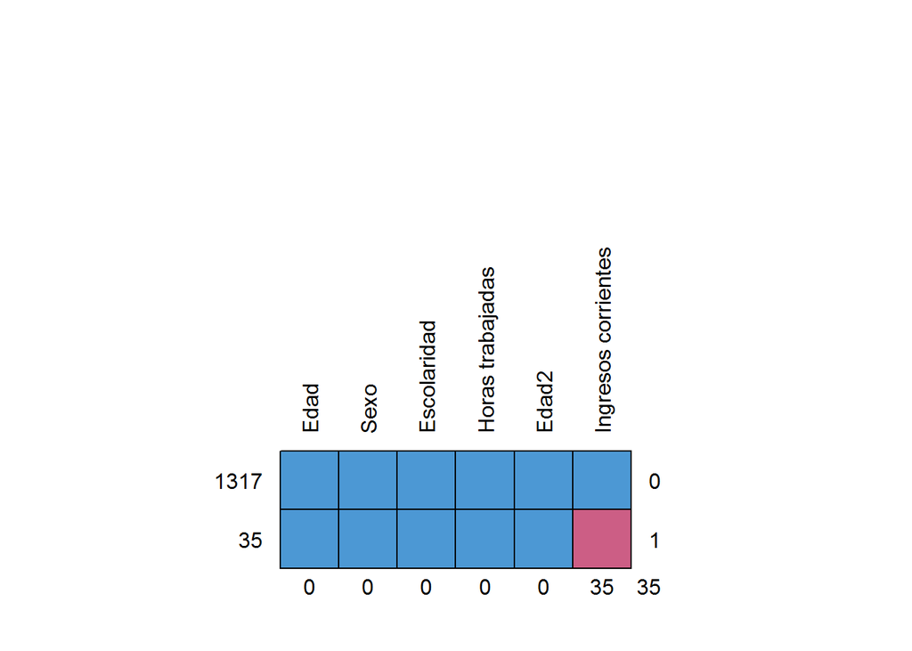

```
##      Edad Sexo Escolaridad Horas trabajadas Edad2 Ingresos corrientes
## 1317    1    1           1                1     1                   1  0
## 35      1    1           1                1     1                   0  1
##         0    0           0                0     0                  35 35
```

# Aplicación: imputación múltiple univariada sobre ingresos corrientes en la GEIH (2022)

Metodológicamente, se propone la imputación de los datos faltantes de la variable de ingresos corrientes por medio de un método de imputación múltiple univariado, más precisamente, el método de coincidencia de medias predictivas en su forma univariada (véase *supra*). La matriz de covariables está determinada por el conjunto de variables explicativas viene determinado por la especificación de la ecuación de Mincer (1974). Por hipótesis, para cada dato faltante, el número de donantes candidatos es $d = 5$; y, siguiendo a van Bureen (2006), se determinan $m = 5$ imputaciones, las cuales corresponden a cinco bases de datos distintas con valores imputados. Esto implica que el método de selección de la unidad donante corresponde, según la clasificación de Andridge & Little (2010), al método (3). La **Tabla 4** presenta, diferenciados según cada una de las cinco bases de datos, los resultados de la imputación.

Tabla 4: Imputación de ingresos corrientes para los individuos diferenciada según la base de datos. Método: método de imputación múltiple univariada según coincidencia de la media predictiva

|  | 1 | 2 | 3 | 4 | 5 |
| --- | --- | --- | --- | --- | --- |
| 35 | 1200000 | 1100000 | 1120000 | 1400000 | 1200000 |
| 48 | 2700000 | 2000000 | 2000000 | 500000 | 1300000 |
| 112 | 490000 | 420000 | 100000 | 1000000 | 570000 |
| 305 | 3000000 | 1630000 | 3000000 | 2500000 | 4600000 |
| 329 | 400000 | 1200000 | 1000000 | 1300000 | 200000 |
| 419 | 40000 | 225000 | 800000 | 500000 | 50000 |
| 552 | 480000 | 40000 | 120000 | 450000 | 40000 |
| 592 | 40000 | 1000000 | 200000 | 1000000 | 1800000 |
| 671 | 1500000 | 1200000 | 1000000 | 1000000 | 1500000 |
| 742 | 900000 | 1100000 | 940000 | 1175000 | 1000000 |
| 832 | 5100000 | 10000000 | 2600000 | 6500000 | 14000000 |
| 854 | 1200000 | 1450000 | 120000 | 700000 | 800000 |
| 898 | 1350000 | 400000 | 1000000 | 240000 | 1350000 |
| 901 | 3500000 | 5000000 | 3950000 | 1200000 | 10000000 |
| 932 | 3500000 | 2300000 | 1150000 | 3500000 | 6000000 |
| 933 | 4000000 | 1500000 | 1000000 | 3800000 | 1320000 |
| 934 | 1000000 | 1300000 | 1200000 | 1600000 | 0 |
| 948 | 1140000 | 600000 | 2000000 | 1100000 | 500000 |
| 975 | 0 | 1000000 | 750000 | 1100000 | 1840000 |
| 1002 | 8000000 | 3300000 | 1500000 | 3800000 | 5800000 |
| 1010 | 2500000 | 1200000 | 2800000 | 0 | 200000 |
| 1027 | 1400000 | 4000000 | 7800000 | 4800000 | 3000000 |
| 1062 | 250000 | 1450000 | 50000 | 164000 | 1000000 |
| 1084 | 60000 | 1000000 | 1050000 | 1000000 | 200000 |
| 1089 | 1400000 | 1100000 | 430000 | 1400000 | 70000 |
| 1094 | 180000 | 1500000 | 1000000 | 800000 | 1600000 |
| 1153 | 2426000 | 2300000 | 2300000 | 4000000 | 6000000 |
| 1154 | 700000 | 300000 | 870000 | 1000000 | 1700000 |
| 1207 | 150000 | 500000 | 210000 | 300000 | 210000 |
| 1223 | 4000000 | 1950000 | 800000 | 800000 | 1000000 |
| 1241 | 1350000 | 1870000 | 500000 | 1870000 | 1300000 |
| 1242 | 450000 | 120000 | 100000 | 100000 | 120000 |
| 1262 | 1000000 | 900000 | 1600000 | 1500000 | 570000 |
| 1295 | 1000000 | 1000000 | 725000 | 1000000 | 1000000 |
| 1299 | 1400000 | 1610000 | 1300000 | 60000 | 920000 |

En lo sucesivo, a partir de las seis bases de datos derivadas —a saber, la base de datos original y las cinco bases de datos con valores imputados—, se presenta un ejercicio de agregación. Los ingresos corrientes individuales, siguiendo la codificación de la GEIH, son agregados a nivel de hogares. La **Tabla 5** presenta la distribución por deciles de los ingresos corrientes para los hogares derivada de cada una de las seis bases de datos.

Tabla 5: distribución por deciles para los ingresos corrientes de los hogares según cada bases de datos (la base de datos original y las cinco bases de datos con valores imputados)

| Decil | Dataset_0 | Dataset_1 | Dataset_2 | Dataset_3 | Dataset_4 | Dataset_5 |
| --- | --- | --- | --- | --- | --- | --- |
| 10% | 259000 | 300000 | 306000 | 300000 | 300000 | 300000 |
| 20% | 800000 | 912000 | 949600 | 900000 | 932000 | 932000 |
| 30% | 1100000 | 1119000 | 1119000 | 1109000 | 1120000 | 1100000 |
| 40% | 1402000 | 1500000 | 1500000 | 1500000 | 1500000 | 1493600 |
| 50% | 1900000 | 1960000 | 1960000 | 1950000 | 1957500 | 1950000 |
| 60% | 2285200 | 2300000 | 2300000 | 2300000 | 2300000 | 2300000 |
| 70% | 2900000 | 2903500 | 2964000 | 2903500 | 2951000 | 2964000 |
| 80% | 3635600 | 3700000 | 3700000 | 3700000 | 3700000 | 3700000 |
| 90% | 5800000 | 6000000 | 5988000 | 5945000 | 6000000 | 6000000 |

Nótese que, de acuerdo con la **Tabla 6**, la descripción general de los ingresos corrientes para los hogares no cambia significativamente según la base de datos considerada. La observación derivada de la **Tabla 6** se verifica en el diagrama de caja. La conclusión es la siguiente: para el propósito de analizar los ingresos corrientes para los hogares, siguiendo la información proporcionada por la GEIH (2022), la diferencia entre los datos de ingresos corrientes no-imputados e imputados no es significativa. El análisis posterior omite la implementación del método de imputación simple y, por simplicidad, omite los datos faltantes.

Tabla 6: Descripción general de los ingresos corrientes de los hogares según cada una de las seis bases de datos (la base de datos no-imputada y las cinco bases de datos imputadas)

|  | Dataset_0 | Dataset_1 | Dataset_2 | Dataset_3 | Dataset_4 | Dataset_5 |
| --- | --- | --- | --- | --- | --- | --- |
|  | Min. : 0 | Min. : 0 | Min. : 0 | Min. : 0 | Min. : 0 | Min. : 0 |
|  | 1st Qu.: 1000000 | 1st Qu.: 1000000 | 1st Qu.: 1000000 | 1st Qu.: 1000000 | 1st Qu.: 1000000 | 1st Qu.: 1000000 |
|  | Median : 1900000 | Median : 1960000 | Median : 1960000 | Median : 1950000 | Median : 1957500 | Median : 1950000 |
|  | Mean : 2930268 | Mean : 2990233 | Mean : 2989983 | Mean : 2979111 | Mean : 2985412 | Mean : 3005745 |
|  | 3rd Qu.: 3205074 | 3rd Qu.: 3282500 | 3rd Qu.: 3292500 | 3rd Qu.: 3282500 | 3rd Qu.: 3290000 | 3rd Qu.: 3282500 |
|  | Max. :82500000 | Max. :82500000 | Max. :82500000 | Max. :82500000 | Max. :82500000 | Max. :82500000 |

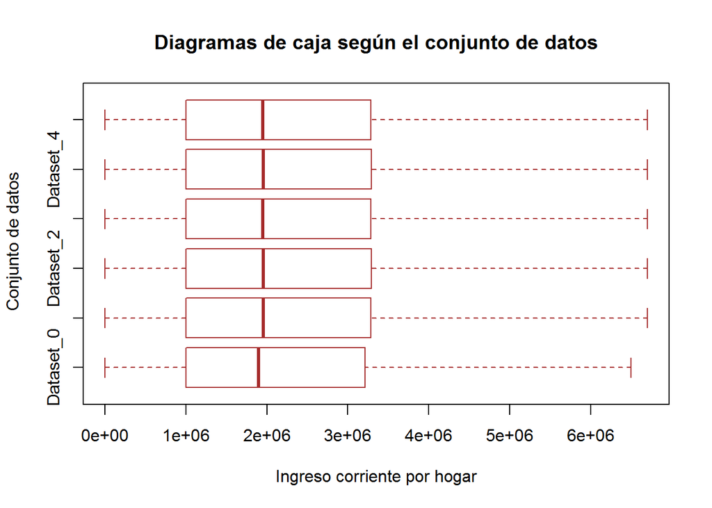